# California_Housing

## California Housing Set

The idea here is similar to what I was doing with the Boston Housing dataset (predicting the median value of homes in a district). In this instance, rather than focus on implementing an optimization algorithm, I try to learn to replicate the kinds of things that an actual ML engineer might do on a day-to-day basis.

Most of this work is taken straight from Aurelien Geron's "Hands-On Machine Learning with Scikit-Learn, Keras & TensorFlow". Although, I did add my own touch with this method, the results of which can be seen below.

I just started working with this dataset (Feb/1/2023). In the near future I'll probably try to come up with my own prediction model and spend some time fine-tuning it.

```python
import os
import tarfile
import urllib
import pandas as pd
import numpy as np

DOWNLOAD_ROOT = "https://raw.githubusercontent.com/ageron/handson-ml2/master/"
HOUSING_PATH = os.path.join("datasets", "housing")
HOUSING_URL = DOWNLOAD_ROOT + "datasets/housing/housing.tgz"

def fetch_housing_data(housing_url=HOUSING_URL, housing_path=HOUSING_PATH):
    os.makedirs(housing_path, exist_ok=True)
    tgz_path = os.path.join(housing_path, "housing.tgz")
    urllib.request.urlretruieve(housing_url, tgz_path)
    housing_tgz = tarfile.open(tgz_path)
    housing_tgz.extractall(path=housing_path)
    housing_tgz.close()

def load_housing_data(housing_path=HOUSING_PATH):
    csv_path = os.path.join(housing_path, "housing.csv")
    return pd.read_csv(csv_path)
```

```python
housing = load_housing_data()
housing.head()
```

|  | longitude | latitude | housing_median_age | total_rooms | total_bedrooms | population | households | median_income | median_house_value | ocean_proximity |
| --- | --- | --- | --- | --- | --- | --- | --- | --- | --- | --- |
| 0 | -122.23 | 37.88 | 41.0 | 880.0 | 129.0 | 322.0 | 126.0 | 8.3252 | 452600.0 | NEAR BAY |
| 1 | -122.22 | 37.86 | 21.0 | 7099.0 | 1106.0 | 2401.0 | 1138.0 | 8.3014 | 358500.0 | NEAR BAY |
| 2 | -122.24 | 37.85 | 52.0 | 1467.0 | 190.0 | 496.0 | 177.0 | 7.2574 | 352100.0 | NEAR BAY |
| 3 | -122.25 | 37.85 | 52.0 | 1274.0 | 235.0 | 558.0 | 219.0 | 5.6431 | 341300.0 | NEAR BAY |
| 4 | -122.25 | 37.85 | 52.0 | 1627.0 | 280.0 | 565.0 | 259.0 | 3.8462 | 342200.0 | NEAR BAY |

```python
housing.info()
```

```
<class 'pandas.core.frame.DataFrame'>
RangeIndex: 20640 entries, 0 to 20639
Data columns (total 10 columns):
 #   Column              Non-Null Count  Dtype
---  ------              --------------  -----
 0   longitude           20640 non-null  float64
 1   latitude            20640 non-null  float64
 2   housing_median_age  20640 non-null  float64
 3   total_rooms         20640 non-null  float64
 4   total_bedrooms      20433 non-null  float64
 5   population          20640 non-null  float64
 6   households          20640 non-null  float64
 7   median_income       20640 non-null  float64
 8   median_house_value  20640 non-null  float64
 9   ocean_proximity     20640 non-null  object
dtypes: float64(9), object(1)
memory usage: 1.6+ MB
```

```python
housing['ocean_proximity'].value_counts()
```

```
<1H OCEAN     9136
INLAND        6551
NEAR OCEAN    2658
NEAR BAY      2290
ISLAND           5
Name: ocean_proximity, dtype: int64
```

```python
housing.describe()
```

|  | longitude | latitude | housing_median_age | total_rooms | total_bedrooms | population | households | median_income | median_house_value |
| --- | --- | --- | --- | --- | --- | --- | --- | --- | --- |
| count | 20640.000000 | 20640.000000 | 20640.000000 | 20640.000000 | 20433.000000 | 20640.000000 | 20640.000000 | 20640.000000 | 20640.000000 |
| mean | -119.569704 | 35.631861 | 28.639486 | 2635.763081 | 537.870553 | 1425.476744 | 499.539680 | 3.870671 | 206855.816909 |
| std | 2.003532 | 2.135952 | 12.585558 | 2181.615252 | 421.385070 | 1132.462122 | 382.329753 | 1.899822 | 115395.615874 |
| min | -124.350000 | 32.540000 | 1.000000 | 2.000000 | 1.000000 | 3.000000 | 1.000000 | 0.499900 | 14999.000000 |
| 25% | -121.800000 | 33.930000 | 18.000000 | 1447.750000 | 296.000000 | 787.000000 | 280.000000 | 2.563400 | 119600.000000 |
| 50% | -118.490000 | 34.260000 | 29.000000 | 2127.000000 | 435.000000 | 1166.000000 | 409.000000 | 3.534800 | 179700.000000 |
| 75% | -118.010000 | 37.710000 | 37.000000 | 3148.000000 | 647.000000 | 1725.000000 | 605.000000 | 4.743250 | 264725.000000 |
| max | -114.310000 | 41.950000 | 52.000000 | 39320.000000 | 6445.000000 | 35682.000000 | 6082.000000 | 15.000100 | 500001.000000 |

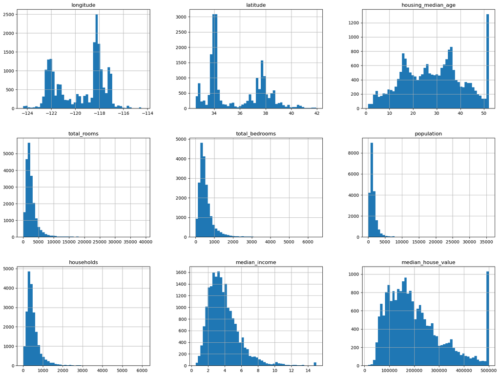

```python
import matplotlib.pyplot as plt
housing.hist(bins=50, figsize=(20, 15))
plt.show()
```

```python
# using a hashing algorithm to ensure that we get the same test set even if the dataset gets updated
from zlib import crc32
def test_set_check(identifier, test_ratio):
    return crc32(np.int64(identifier)) & 0xffffffff < test_ratio * 2**32

def split_train_test_by_id(data, test_ratio, id_column):
    ids = data[id_column]
    in_test_set = ids.apply(lambda id_: test_set_check(id_, test_ratio))
    return data.loc[~in_test_set], data.loc[in_test_set]
```

```python
housing_with_id = housing.reset_index()
train_set, test_set = split_train_test_by_id(housing_with_id, 0.2, "index")
```

```python
# this library function does the same thing but with extra features, like using identical indices for multiple dataframes
from sklearn.model_selection import train_test_split
train_set, test_set = train_test_split(housing, test_size=0.2, random_state=42)
```

```python
housing["income_cat"] = pd.cut(housing["median_income"],
                               bins=[0, 1.5, 3.0, 4.5, 6., np.inf],
                               labels=[1, 2, 3, 4, 5])
```

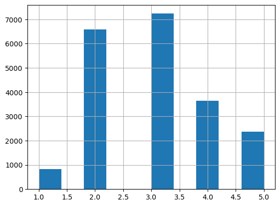

```python
housing["income_cat"].hist()
```

```python
from sklearn.model_selection import StratifiedShuffleSplit
split = StratifiedShuffleSplit(n_splits=1, test_size=0.2, random_state=42)
for train_index, test_index in split.split(housing, housing["income_cat"]):
    strat_train_set = housing.loc[train_index]
    strat_test_set = housing.loc[test_index]
```

```python
strat_test_set["income_cat"].value_counts() / len(strat_test_set)
```

```
3    0.350533
2    0.318798
4    0.176357
5    0.114341
1    0.039971
Name: income_cat, dtype: float64
```

```python
for set_ in (strat_train_set, strat_test_set):
    set_.drop("income_cat", axis=1, inplace=True)
```

```python
housing = strat_train_set.copy()
```

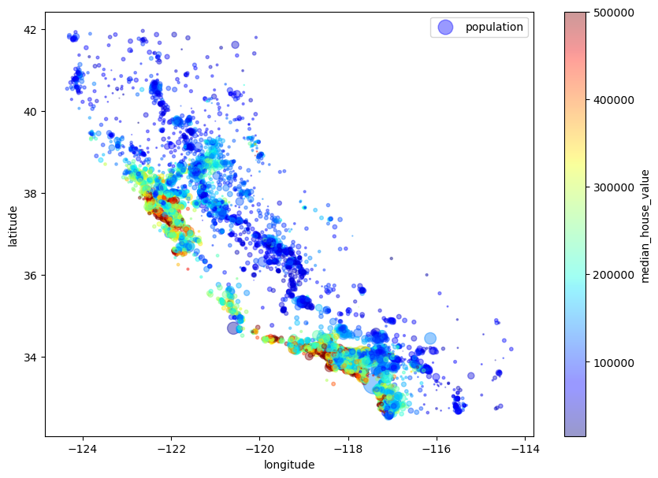

```python
housing.plot(kind='scatter', x='longitude', y='latitude', alpha=0.4,
    s=housing["population"]/100, label='population', figsize=(10,7),
    c="median_house_value", cmap=plt.get_cmap("jet"), colorbar=True)
plt.legend()
```

```python
corr_matrix = housing.corr()
```

```python
corr_matrix["median_house_value"].sort_values(ascending=False)
```

```
median_house_value    1.000000
median_income         0.687151
total_rooms           0.135140
housing_median_age    0.114146
households            0.064590
total_bedrooms        0.047781
population           -0.026882
longitude            -0.047466
latitude             -0.142673
Name: median_house_value, dtype: float64
```

```
array([[<AxesSubplot: xlabel='median_house_value', ylabel='median_house_value'>,
        <AxesSubplot: xlabel='median_income', ylabel='median_house_value'>,
        <AxesSubplot: xlabel='total_rooms', ylabel='median_house_value'>,
        <AxesSubplot: xlabel='housing_median_age', ylabel='median_house_value'>],
       [<AxesSubplot: xlabel='median_house_value', ylabel='median_income'>,
        <AxesSubplot: xlabel='median_income', ylabel='median_income'>,
        <AxesSubplot: xlabel='total_rooms', ylabel='median_income'>,
        <AxesSubplot: xlabel='housing_median_age', ylabel='median_income'>],
       [<AxesSubplot: xlabel='median_house_value', ylabel='total_rooms'>,
        <AxesSubplot: xlabel='median_income', ylabel='total_rooms'>,
        <AxesSubplot: xlabel='total_rooms', ylabel='total_rooms'>,
        <AxesSubplot: xlabel='housing_median_age', ylabel='total_rooms'>],
       [<AxesSubplot: xlabel='median_house_value', ylabel='housing_median_age'>,
        <AxesSubplot: xlabel='median_income', ylabel='housing_median_age'>,
        <AxesSubplot: xlabel='total_rooms', ylabel='housing_median_age'>,
        <AxesSubplot: xlabel='housing_median_age', ylabel='housing_median_age'>]],
      dtype=object)
```

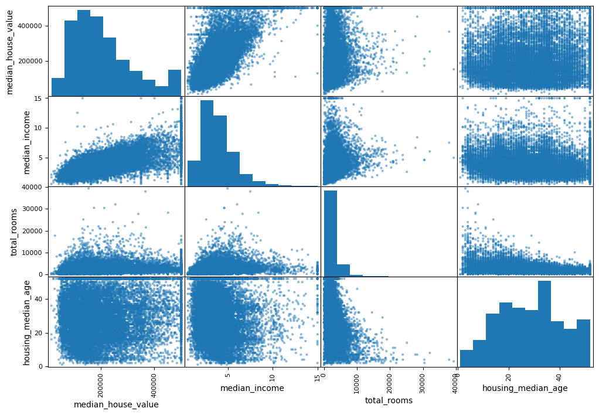

```python
from pandas.plotting import scatter_matrix
attributes = ["median_house_value", "median_income", "total_rooms", "housing_median_age"]
scatter_matrix(housing[attributes], figsize=(12, 8))
```

```python
# returns a subset of df in which all the values of var fall between min and max inclusive
def get_attribute_range(X, col, min, max):
    return X[(X[:, col] >= min) & (X[:, col] <= max)]
```

### data-cleaning method

```python
from math import floor, ceil

def remove_caps(df, col, step, sensitivity=4, num_iters=2):

    if sensitivity < 0 or sensitivity > 10:
        raise Exception
    threshold = list(range(10, 0, -1))[sensitivity]

    for _ in range(num_iters):
        min_ = floor(df.min(axis=0)[col])
        max_ = ceil(df.max(axis=0)[col])
        min_range = np.arange(min_, max_ - step, step)
        max_range = np.arange(min_ + step + 1, max_, step)
        for i, j in zip(min_range, max_range):
            if max_ - j < step:
                j = max_
            frame = df[(df[col] >= i) & (df[col] <= j)]
            grouped = frame.groupby([col]).size()
            std_dev = grouped / np.std(grouped)
            for elem in grouped[std_dev > threshold].index:
                df = df[df[col] != elem]
    return df

housing_cleaned = housing.copy()

housing_cleaned = remove_caps(housing, 'median_house_value', step=10000, sensitivity=4)
```

### Data-cleaning method results

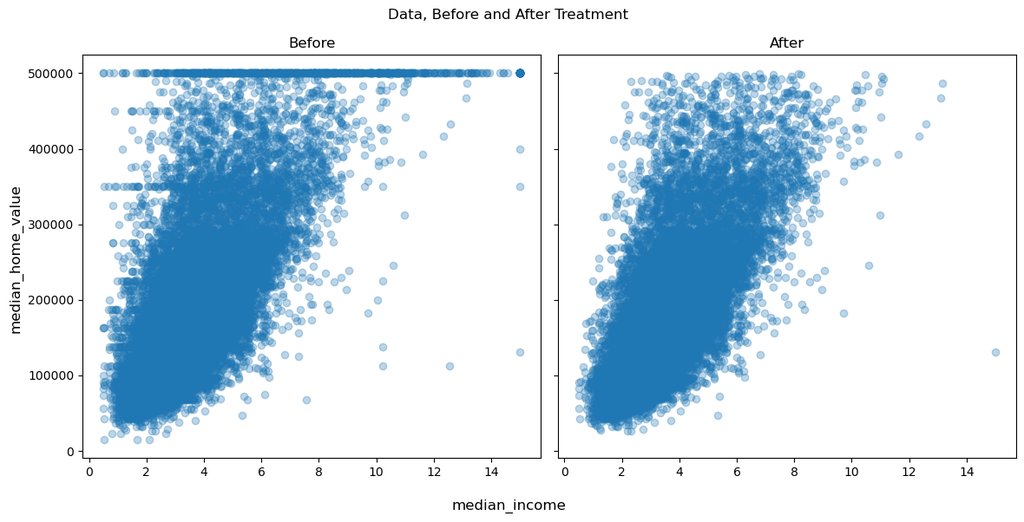

```python
fig, (ax1, ax2) = plt.subplots(1, 2, sharey=True, figsize=(12, 6))
fig.suptitle("Data, Before and After Treatment")
fig.supxlabel('median_income')
fig.supylabel('median_home_value')

x, y = housing['median_income'].values, housing['median_house_value'].values
ax1.scatter(x, y, alpha=0.3)
ax1.set_title('Before')

x, y = housing_cleaned['median_income'].values, housing_cleaned['median_house_value'].values
ax2.scatter(x, y, alpha=0.3)
ax2.set_title('After')

fig.tight_layout()
```

```python
housing = housing_cleaned
housing.loc[:, 'rooms_per_household'] = housing['total_rooms'] / housing['households']
housing['bedrooms_per_room'] = housing['total_bedrooms'] / housing['total_rooms']
housing['population_per_household'] = housing['population'] / housing['households']
corr_matrix = housing.corr()
corr_matrix['median_house_value'].sort_values(ascending=False)
```

```
median_house_value          1.000000
median_income               0.679620
rooms_per_household         0.156789
total_rooms                 0.147754
households                  0.090817
total_bedrooms              0.069606
housing_median_age          0.067313
population                  0.007442
longitude                  -0.043006
latitude                   -0.154836
population_per_household   -0.184398
bedrooms_per_room          -0.287038
Name: median_house_value, dtype: float64
```

We still have rows that have no value for total_bedrooms so let's take care of that now.

```python
from sklearn.impute import SimpleImputer
imputer = SimpleImputer(strategy='median')
housing_num = housing.drop('ocean_proximity', axis=1)
imputer.fit(housing_num)
X = imputer.transform(housing_num)
housing_tr = pd.DataFrame(X, columns=housing_num.columns, index=housing_num.index)
temp_col = housing.loc[:, 'ocean_proximity']
temp_housing = housing_tr
temp_housing['ocean_proximity'] = temp_col
housing = temp_housing
```

```python
housing = strat_train_set  # starting from scratch
```

```python
from sklearn.base import BaseEstimator, TransformerMixin

rooms_ix, bedrooms_ix, population_ix, households_ix = 3, 4, 5, 6

class CombinedAttributesAdder(BaseEstimator, TransformerMixin):

    def __init__(self, add_bedrooms_per_room=True):  # no *args or **kargs
        self.add_bedrooms_per_room = add_bedrooms_per_room

    def fit(self, X, y=None):
        return self     # nothing to do here

    def transform(self, X):
        rooms_per_household = X[:, rooms_ix] / X[:, households_ix]
        population_per_household = X[:, population_ix] / X[:, households_ix]
        if self.add_bedrooms_per_room:
            bedrooms_per_room = X[:, bedrooms_ix] / X[:, rooms_ix]
            return np.c_[X, rooms_per_household, population_per_household, bedrooms_per_room]
        else:
            return np.c_[X, rooms_per_household, population_per_household]

attr_adder = CombinedAttributesAdder(add_bedrooms_per_room=False)
housing_extra_attribs = attr_adder.transform(housing.values)
```

```python
median_house_value_ix = 8

class RemoveCaps(BaseEstimator, TransformerMixin):

    def __init__(self, step:int=10000, sensitivity:int=4, num_iters:int=2):
        self.step=step
        self.sensitivity=sensitivity
        self.num_iters=num_iters

    def fit(self, X, y=None):
        return self     # nothing to do here

    def transform(self, X):
        if self.sensitivity < 0 or self.sensitivity > 10:
            raise Exception('senisitivity must be and integer between 0 and 10 (inclusive)')
        threshold = list(range(10, 0, -1))[self.sensitivity]

        for _ in range(self.num_iters):
            sup_min = floor(np.amin(X[:, median_house_value_ix]))
            sup_max = ceil(np.amax(X[:, median_house_value_ix]))
            min_range = np.arange(sup_min, sup_max - self.step, self.step)
            max_range = np.arange(sup_min + self.step + 1, sup_max, self.step)
            for min_, max_ in zip(min_range, max_range):
                if sup_max - max_ < self.step:
                    max_ = sup_max
                slice_ = get_attribute_range(X, median_house_value_ix, min_, max_)
                unique = np.unique(slice_[:, median_house_value_ix])
                frequencies = [np.sum(slice_[:, median_house_value_ix] == unique_elem) for unique_elem in unique]
                avg = np.mean(frequencies)
                std = np.std(frequencies)
                if std == 0:
                    above_threshold_index = np.array([True for _ in unique])
                else:
                    above_threshold_index = (frequencies - avg) / std > threshold
                for elem in unique[above_threshold_index]:
                    X = X[X[:, median_house_value_ix] != elem]
        return X
```

```python
housing = remove_caps(housing, 'median_house_value', 10000, sensitivity=4)
housing_num = housing.drop('ocean_proximity', axis=1)
```

```python
from sklearn.pipeline import Pipeline
from sklearn.preprocessing import StandardScaler, OneHotEncoder

num_pipeline = Pipeline([
    ('imputer', SimpleImputer(strategy='median')),
    ('attribs_adder', CombinedAttributesAdder()),
    ('std_scaler', StandardScaler())
])
```

```python
housing_labels = housing.loc[:, 'median_house_value']
housing = housing.drop('median_house_value', axis=1)
housing_num = housing.drop('ocean_proximity', axis=1)
```

```python
from sklearn.compose import ColumnTransformer

num_attribs = list(housing_num)
cat_attribs = ['ocean_proximity']

full_pipeline = ColumnTransformer([
    ('num', num_pipeline, num_attribs),
    ('cat', OneHotEncoder(), cat_attribs)
])
```

```python
housing_prepared = full_pipeline.fit_transform(housing)
```

```python
from sklearn.linear_model import LinearRegression
lin_reg = LinearRegression()
lin_reg.fit(housing_prepared, housing_labels)
```

```
LinearRegression()
```

```python
some_data = housing.iloc[:5]
some_labels = housing_labels.iloc[:5]
some_data_prepared = full_pipeline.transform(some_data)
print("Predictions: ", lin_reg.predict(some_data_prepared))
print("Labels: ", list(some_labels))
```

```
Predictions:  [ 83248.90567229 300054.72717201 145069.18679172 235840.39745727
 193242.29462711]
Labels:  [72100.0, 279600.0, 82700.0, 238300.0, 165700.0]
```

```python
from sklearn.metrics import mean_squared_error
housing_predictions = lin_reg.predict(housing_prepared)
lin_mse = mean_squared_error(housing_labels, housing_predictions)
lin_rmse = np.sqrt(lin_mse)
lin_rmse
```

```
56330.81387588117
```

```python
from sklearn.tree import DecisionTreeRegressor

tree_reg = DecisionTreeRegressor()
tree_reg.fit(housing_prepared, housing_labels)
```

```
DecisionTreeRegressor()
```

```python
housing_predictions = tree_reg.predict(housing_prepared)
tree_mse = mean_squared_error(housing_labels, housing_predictions)
tree_rmse = np.sqrt(tree_mse)
tree_rmse
```

```
0.0
```

```python
from sklearn.model_selection import cross_val_score
scores = cross_val_score(tree_reg, housing_prepared, housing_labels, scoring="neg_mean_squared_error", cv=10)
tree_rmse_scores = np.sqrt(-scores)
```

```python
def display_scores(scores):
    print("Scores: ", scores)
    print("Mean: ", scores.mean())
    print("Standard deviation: ", scores.std())
```

```python
display_scores(tree_rmse_scores)
```

```
Scores:  [59539.25103892 60551.73864739 60635.73321777 59686.51415512
 58360.20549513 58564.619019   58500.02046972 58604.9179469
 58015.05298239 55906.81403677]
Mean:  58836.48670091105
Standard deviation:  1308.4772204723402
```

```python
from sklearn.ensemble import RandomForestRegressor
forest_reg = RandomForestRegressor()
forest_reg.fit(housing_prepared, housing_labels)
forest_scores = cross_val_score(forest_reg, housing_prepared, housing_labels, scoring='neg_mean_squared_error', cv=10)
forest_rmse = np.sqrt(-forest_scores)
```

```python
display_scores(forest_rmse)
```

```
Scores:  [41852.91965976 41832.89281314 41363.83523515 43074.84199125
 41193.13832345 42635.12397648 42557.56020074 43643.17113671
 40522.62494429 43342.41354399]
Mean:  42201.85218249587
Standard deviation:  961.8788638744394
```

### References

Géron Aurélien (2023) Hands-on machine learning with scikit-learn, keras and tensorflow: Concepts, tools, and techniques to build Intelligent Systems. Sebastapol, CA: O'Reilly.